# BTC project

PREDICTING CRYPTO PRICES

I'm going to try to find some trends in the prices of BTC, Etherium, and Monero. First I'll explore the historical relationship between their prices and then attempt some methods to predict whether a given observation is more likely to increase or decrease with the next time-step

STEP 1: GET THE DATA This is a dataset of historical cryptocurrency prices that I found on Kaggle. This dataset is outdated, being 2-3 years old, but I do not expect the nature of these relationships to have significantly changed during that period. The dataset I use can be found at https://www.kaggle.com/sudalairajkumar/cryptocurrencypricehistory?select=monero_price.csv. There is only price data for all coins besides btc and eth.

```python
import pandas as pd
import numpy as np

btc_prices = pd.read_csv("bitcoin_price.csv")[::-1].reset_index(drop=True)
btc_data = pd.read_csv("bitcoin_dataset.csv")

eth_prices = pd.read_csv("ethereum_price.csv")[::-1].reset_index(drop=True)
eth_data = pd.read_csv("ethereum_dataset.csv")

mon_prices = pd.read_csv("monero_price.csv")[::-1].reset_index(drop=True)

#btc_data = btc_data.reindex(index=btc_data.index[::-1]).reset_index(drop=True)
#eth_data = eth_data.reindex(index=eth_data.index[::-1]).reset_index(drop=True)

display(eth_data.head())
display(btc_data.head())
display(mon_prices.head())
```

|  | Date(UTC) | UnixTimeStamp | eth_etherprice | eth_tx | eth_address | eth_supply | eth_marketcap | eth_hashrate | eth_difficulty | eth_blocks | eth_uncles | eth_blocksize | eth_blocktime | eth_gasprice | eth_gaslimit | eth_gasused | eth_ethersupply | eth_ens_register |
| --- | --- | --- | --- | --- | --- | --- | --- | --- | --- | --- | --- | --- | --- | --- | --- | --- | --- | --- |
| 0 | 7/30/2015 | 1438214400 | 0.0 | 8893 | 9205 | 7.204931e+07 | 0.0 | 11.5297 | 0.121 | 6912 | 1299 | 644 | 4.46 | 0 | 0 | 0 | 39316.09375 | NaN |
| 1 | 7/31/2015 | 1438300800 | 0.0 | 0 | 9361 | 7.208550e+07 | 0.0 | 51.4594 | 0.603 | 6863 | 511 | 582 | 12.58 | 0 | 0 | 0 | 36191.71875 | NaN |
| 2 | 8/1/2015 | 1438387200 | 0.0 | 0 | 9476 | 7.211320e+07 | 0.0 | 57.7845 | 0.887 | 5293 | 334 | 575 | 16.34 | 0 | 0 | 0 | 27705.93750 | NaN |
| 3 | 8/2/2015 | 1438473600 | 0.0 | 0 | 9563 | 7.214143e+07 | 0.0 | 67.9224 | 1.020 | 5358 | 394 | 581 | 16.12 | 0 | 0 | 0 | 28223.43750 | NaN |
| 4 | 8/3/2015 | 1438560000 | 0.0 | 0 | 9639 | 7.216940e+07 | 0.0 | 74.5737 | 1.126 | 5280 | 443 | 587 | 16.37 | 0 | 0 | 0 | 27976.71875 | NaN |

|  | Date | btc_market_price | btc_total_bitcoins | btc_market_cap | btc_trade_volume | btc_blocks_size | btc_avg_block_size | btc_n_orphaned_blocks | btc_n_transactions_per_block | btc_median_confirmation_time | ... | btc_cost_per_transaction_percent | btc_cost_per_transaction | btc_n_unique_addresses | btc_n_transactions | btc_n_transactions_total | btc_n_transactions_excluding_popular | btc_n_transactions_excluding_chains_longer_than_100 | btc_output_volume | btc_estimated_transaction_volume | btc_estimated_transaction_volume_usd |
| --- | --- | --- | --- | --- | --- | --- | --- | --- | --- | --- | --- | --- | --- | --- | --- | --- | --- | --- | --- | --- | --- |
| 0 | 2010-02-23 00:00:00 | 0.0 | 2110700.0 | 0.0 | 0.0 | 0.0 | 0.000216 | 0.0 | 1.0 | 0.0 | ... | 25100.000000 | 0.0 | 252.0 | 252.0 | 42613.0 | 252.0 | 252.0 | 12600.0 | 50.0 | 0.0 |
| 1 | 2010-02-24 00:00:00 | 0.0 | 2120200.0 | 0.0 | 0.0 | 0.0 | 0.000282 | 0.0 | 1.0 | 0.0 | ... | 179.245283 | 0.0 | 195.0 | 196.0 | 42809.0 | 196.0 | 196.0 | 14800.0 | 5300.0 | 0.0 |
| 2 | 2010-02-25 00:00:00 | 0.0 | 2127600.0 | 0.0 | 0.0 | 0.0 | 0.000227 | 0.0 | 1.0 | 0.0 | ... | 1057.142857 | 0.0 | 150.0 | 150.0 | 42959.0 | 150.0 | 150.0 | 8100.0 | 700.0 | 0.0 |
| 3 | 2010-02-26 00:00:00 | 0.0 | 2136100.0 | 0.0 | 0.0 | 0.0 | 0.000319 | 0.0 | 1.0 | 0.0 | ... | 64.582059 | 0.0 | 176.0 | 176.0 | 43135.0 | 176.0 | 176.0 | 29349.0 | 13162.0 | 0.0 |
| 4 | 2010-02-27 00:00:00 | 0.0 | 2144750.0 | 0.0 | 0.0 | 0.0 | 0.000223 | 0.0 | 1.0 | 0.0 | ... | 1922.222222 | 0.0 | 176.0 | 176.0 | 43311.0 | 176.0 | 176.0 | 9101.0 | 450.0 | 0.0 |

5 rows × 24 columns

|  | Date | Open | High | Low | Close | Volume | Market Cap |
| --- | --- | --- | --- | --- | --- | --- | --- |
| 0 | May 21, 2014 | 2.47 | 2.65 | 1.23 | 1.60 | 246,540 | 2,079,640 |
| 1 | May 22, 2014 | 1.59 | 2.19 | 1.36 | 2.10 | 132,918 | 1,371,470 |
| 2 | May 23, 2014 | 2.05 | 3.43 | 2.05 | 2.96 | 266,852 | 1,816,200 |
| 3 | May 24, 2014 | 2.92 | 4.01 | 2.62 | 3.70 | 248,028 | 2,653,720 |
| 4 | May 25, 2014 | 4.04 | 4.04 | 2.80 | 3.14 | 283,545 | 3,774,890 |

I will begin by charting each coin's price over time and seeing if visual cycles can be identified, and then by searching for correlation between the prices of the 3 coins to see if they are good predictors of one another's value. To do this, I will first create a new dataframe containing the prices of each coin across the widest avaliable date range

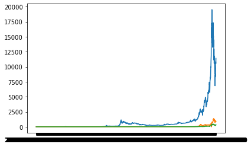

```python
import matplotlib.pyplot as plt
import datetime
#I will convert dates to days since btc origin

prices = btc_data[['Date','btc_market_price']]
prices['eth'] = 0
prices['mon'] = 0
zeroth_day = datetime.datetime.strptime("2010-02-23 00:00:00", '%Y-%m-%d %H:%M:%S')
for index, row in eth_data.iterrows():
    days_since = (datetime.datetime.strptime(row['Date(UTC)'], '%m/%d/%Y')-zeroth_day).days
    prices['eth'].iloc[days_since] = row['eth_etherprice']

for index, row in mon_prices.iterrows():
    days_since = (datetime.datetime.strptime(row['Date'], '%b %d, %Y')-zeroth_day).days
    prices['mon'].iloc[days_since] = row['Open']

prices.columns = ['Date', 'btc', 'eth', 'mon']
plt.plot(prices['Date'],prices['btc'])
plt.plot(prices['Date'],prices['eth'])
plt.plot(prices['Date'],prices['mon'])
```

This graph shows the prices of each coin, but it is not entirely clear what the relationship between the three coins is. To help remedy this I will present a normalized graph, in which each coin's score is calculated in terms of standard deviations from its own mean. This will put the coins on a level playing field, so we can study their relative development instead of their absolute development

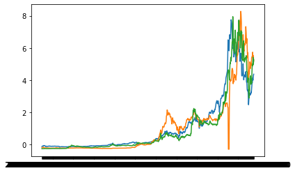

```python
pricesN = (prices[['btc','eth','mon']]-prices[['btc','eth','mon']].mean())/prices[['btc','eth','mon']].std()
plt.plot(prices['Date'][2300:],pricesN['btc'][2300:])
plt.plot(prices['Date'][2300:],pricesN['eth'][2300:])
plt.plot(prices['Date'][2300:],pricesN['mon'][2300:])
```

So, it certainly looks like there is a relationship, as intuition would suggest. We can now quantify this relationship by finding the correlation.

```python
btc_eth_corr = prices['btc'].corr(prices['eth'])
btc_mon_corr = prices['btc'].corr(prices['mon'])
eth_mon_corr = prices['eth'].corr(prices['mon'])
print(btc_eth_corr)
print(btc_mon_corr)
print(eth_mon_corr)
```

```
0.9062143713635288
0.9659378913230571
0.9493061486956695
```

As one might expect, each coin's value is highly correlated with the values of the other two coins.

I am unsure of whether this method will prove useful--after all, it does not take into account anything but the data of a single observation when making a prediction. It will not be able to account for long-term trends or seasonal cycles. It cannot explain market forces. However, I believe it is plausibly helpful as an exploration of the important factors in predicting price

As a first step, we will label the parameters. Then, prune away the parameters we do not want to use.

```python
#LABELLING
#BTC
#first day for which i have daily data
btc_daily_data_beg = datetime.datetime.strptime("2013-04-28", '%Y-%m-%d')
start = (btc_daily_data_beg-zeroth_day).days

increasing = np.zeros(len(btc_data.index))
for index, row in btc_data.iterrows():
    if index < start:
        if row['btc_market_price'] > btc_data['btc_market_price'].iloc[index+1]:
            increasing[index] = 1
    else:
        if btc_prices['Close'].iloc[index-start] > btc_prices['Open'].iloc[index-start]:
            increasing[index] = 1
btc_data['increasing'] = increasing

#ETH
eth_daily_data_beg = datetime.datetime.strptime("2015-08-07", '%Y-%m-%d')
eth_zero = datetime.datetime.strptime("2015-07-30", '%Y-%m-%d')
eth_start = (eth_daily_data_beg-eth_zero).days
increasing = np.zeros(len(eth_data.index))
for index, row in eth_data.iterrows():
    if index < eth_start:
        if row['eth_etherprice'] > eth_data['eth_etherprice'].iloc[index+1]:
            increasing[index] = 1
    else:
        if eth_prices['Close'].iloc[index-eth_start] > eth_prices['Open'].iloc[index-eth_start]:
            increasing[index] = 1
eth_data['increasing'] = increasing
```

Now we will choose the parameters of interest. We do not expect every variable to be useful in the prediction of prices, so we will limit our analysis to:

BTC:

# of addresses (16)

# of coins (2)

ETH:

# of new coins (16)

# of addresses (4)

hash rate (7) difficulty (8)

First, we will use a random-forest model to predict prices based off of an observation directly. Then, we will try both a logistic regression model and a random forest model to predict whether an observation is increasing.

We will use K-fold validation-- the dataset will be randomly broken up 10 times into training data and test data. This will help us prevent overfitting.

```python
#FIRST- DIRECT PRICE PREDICTION with 10-fold cross validation
from sklearn.model_selection import KFold
from sklearn.ensemble import RandomForestRegressor
from sklearn.tree import export_graphviz
#BTC
x = btc_data.iloc[:,[2,5,10,11,16]]
#x = btc_data.iloc[:,2:21]
y = btc_data['btc_market_price']

kf = KFold(10, shuffle=True)
scores = []
model = RandomForestRegressor(10)

for train, test in kf.split(btc_data):
    xtrain = x.iloc[train]
    xtest = x.iloc[test]
    ytrain = y.iloc[train]
    ytest = y.iloc[test]
    model.fit(xtrain,ytrain)
    scores.append(model.score(xtest, ytest))
print("btc model error: "+ str(np.mean(scores)))


#ETH
x = eth_data.iloc[:,[4,7,8,16]]
y = eth_data['eth_etherprice']
scores = []
for train, test in kf.split(eth_data):
    xtrain = x.iloc[train]
    xtest = x.iloc[test]
    ytrain = y.iloc[train]
    ytest = y.iloc[test]
    model.fit(xtrain,ytrain)
    scores.append(model.score(xtest, ytest))
print("eth model error: "+ str(np.mean(scores)))
```

```
btc model error: 0.9940705999592698
eth model error: 0.9917805514251625
```

These errors look very good-- given this data, clearly one can make a very accurate prediction of price. Clearly, this will not help us if our goal is to predict the price of a coin tomorrow- we will not have forecasts for the requisite data. So now it is time to attempt the primitive method we discussed earlier: use logistic regression and decision trees to predict based on the data of today whether the price will be higher tomorrow or not. I think to do a real BTC price prediction would require reinforcement learning techniques, but perhaps we will be able to take some preliminary steps towards understanding the problem through this regression technique.

```python
#Now, the logistic regression model
from sklearn.linear_model import LogisticRegression

#first i will find out what percentage is increasing
print("percent btc increasing: "+str(btc_data['increasing'].mean()))
print("percent eth increasing: "+str(eth_data['increasing'].mean()))

#BTC
x = btc_data.iloc[:,[2,3,5,6,7,8,9,10,11,12,13,14,15,16]]
y = btc_data['increasing']

scores = []
model = LogisticRegression()
kf = KFold(10, shuffle=True)

for train, test in kf.split(btc_data):
    xtrain = x.iloc[train]
    xtest = x.iloc[test]
    ytrain = y.iloc[train]
    ytest = y.iloc[test]
    model.fit(xtrain,ytrain)
    scores.append(model.score(xtest, ytest))
print("btc model error: "+ str(np.mean(scores)))

x = eth_data.iloc[:,[4,7,8,16]]
y = eth_data['increasing']
scores = []
for train, test in kf.split(eth_data):
    xtrain = x.iloc[train]
    xtest = x.iloc[test]
    ytrain = y.iloc[train]
    ytest = y.iloc[test]
    model.fit(xtrain,ytrain)
    scores.append(model.score(xtest, ytest))
print("eth model error: "+ str(np.mean(scores)))
```

```
percent btc increasing: 0.5006849315068493
percent eth increasing: 0.48394004282655245
btc model error: 0.488013698630137
eth model error: 0.5331045527339281
```

50% of observations are increasing, and our models have accuracy scores of only about 50%-- they are barely deviating from a pure guess. So, perhaps as expected, this method is unhelpful. I will try a tree model but have no reason to expect different results.

```python
#BTC
x = btc_data.iloc[:,[2,3,5,6,7,8,9,10,11,12,13,14,15,16]]
y = btc_data['increasing']

scores = []
model = RandomForestRegressor()
kf = KFold(10, shuffle=True)

for train, test in kf.split(btc_data):
    xtrain = x.iloc[train]
    xtest = x.iloc[test]
    ytrain = y.iloc[train]
    ytest = y.iloc[test]
    model.fit(xtrain,ytrain)
    scores.append(model.score(xtest, ytest))
print("btc model error: "+ str(np.mean(scores)))

x = eth_data.iloc[:,[4,7,8,16]]
y = eth_data['increasing']
scores = []
for train, test in kf.split(eth_data):
    xtrain = x.iloc[train]
    xtest = x.iloc[test]
    ytrain = y.iloc[train]
    ytest = y.iloc[test]
    model.fit(xtrain,ytrain)
    scores.append(model.score(xtest, ytest))
print("eth model error: "+ str(np.mean(scores)))
```

```
btc model error: 0.005278604336311288
eth model error: -0.24013733350761307
```

These scores are not good. Now that this method has been disproven, I will use some time-series methods. To help identify proper hyperparameters, I will first plot the autocorrelation functions for both BTC and ETH.

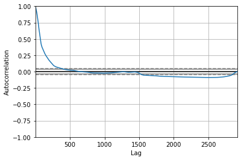

```python
#from statsmodels.tsa.statespace.arima import ARIMA
from statsmodels.graphics import tsaplots
from pandas.plotting import autocorrelation_plot
#BTC
autocorrelation_plot(btc_data['btc_market_price'])
#tsaplots.plot_pacf(btc_data['btc_market_price'])
```

These graphs mean that the BTC model can be largely explained with an autocorrelation of perhaps 100- though this is a visual estimate. For ETH this value looks to be closer to 70-100.

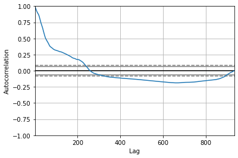

```python
autocorrelation_plot(eth_data['eth_etherprice'])
```

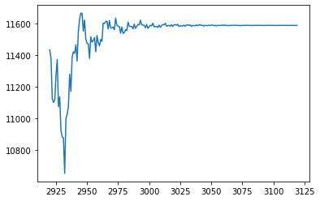

```python
from statsmodels.tsa.arima.model import ARIMA
#BTC
y = btc_data['btc_market_price']
#plt.plot(btc_data['Date'], btc_data['btc_market_price'])
model = ARIMA(y, order=(20,1,0))
fit = model.fit()
plt.plot(fit.forecast(200))
```

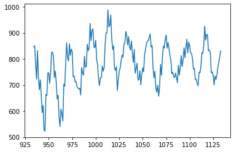

```python
y = eth_data['eth_etherprice']
model = ARIMA(y, order=(50,1,0))
fit = model.fit()
plt.plot(fit.forecast(200))
```